# Anàlisi de la cohort de KIRC utilitzant informació de MCN

## Preparació de les dades per a l’anàlisi

El fitxer de dades amb informació de l’estat WGD (Bielski) conté 250 casos de la cohort de KIRC.

Tenim 611 fitxers de recomptes de la cohort de KIRC.

L’anàlisi inclourà 247 mostres, 217 mostres sense WGD i 30 mostres amb WGD. Un 12% de les mostres de l’anàlisi han patit WGD.

La mida de les llibreries varia entre 3.827799710^{7} i 1.533930210^{8} i la mida mitjana és de 9.612869410^{7}.

## Pre-processament de les dades

Per a la filtració s’ha utilitzat un llindar de CPM de 0.1 i s’han filtrat 34786 gens, és a dir un 58% dels gens que teníem inicialment.

El rang de valors dels factors de normalització és de 0.5620617, 1.6452928.

## Exploració de les dades

### Gràfics de densitat

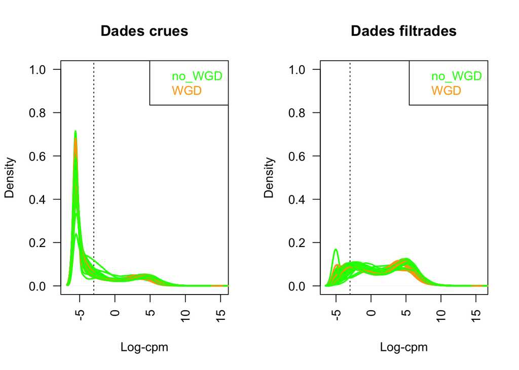

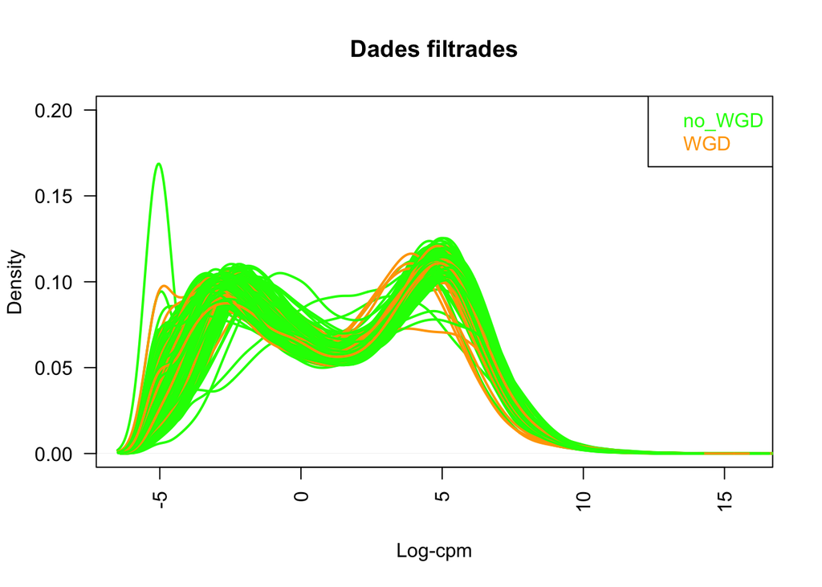

### Gràfic d’escalat multidimensional

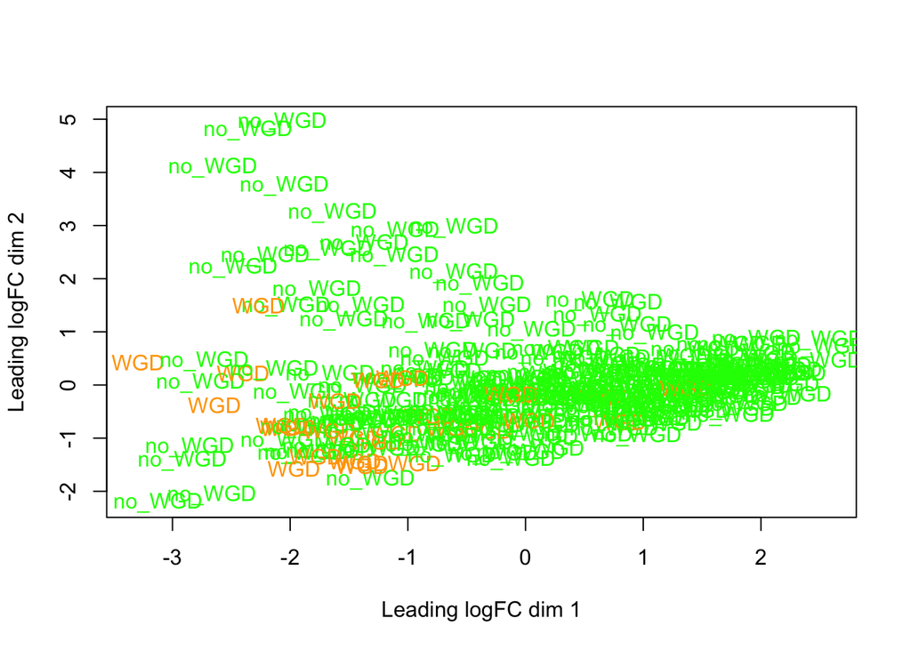

### Heatmap del gens més variables

Matriu de distàncies dels logCPM dels gens més variables. En aquest cas extraiem els 500 gens més variables a partir de les dades filtrades i normalitzades.

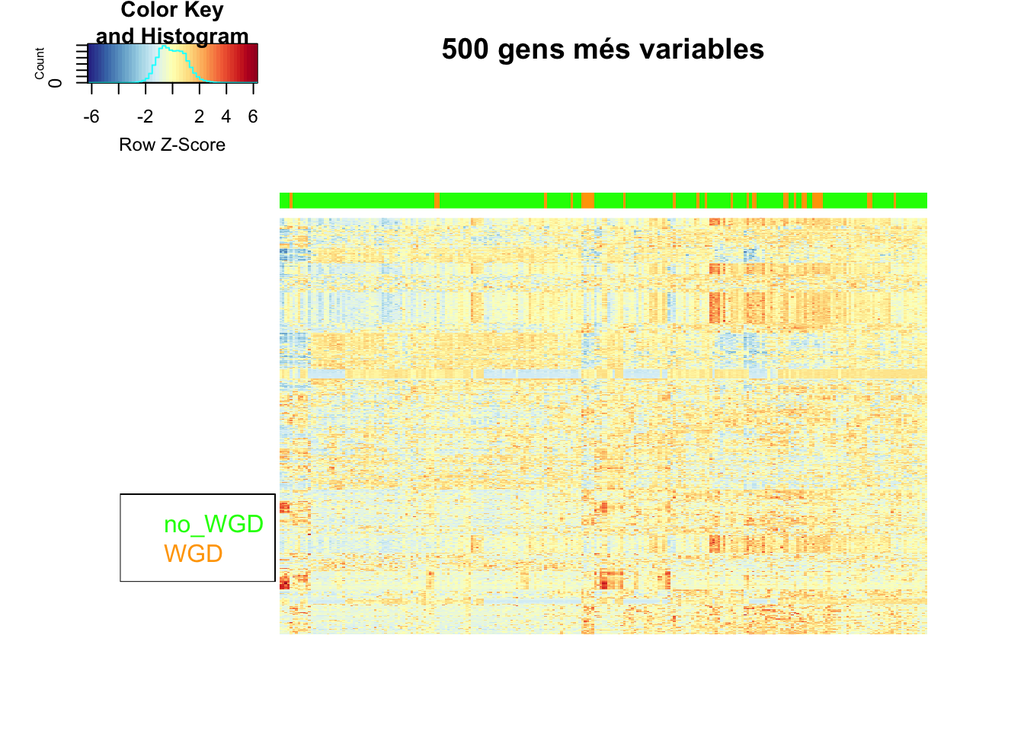

## Resultats de l’anàlisi d’expressió diferencial

### Nombre de gens diferencialment expressats

Contrastos amb p-valor ajustat (FDR) inferior a 0.05:

```
##        WGDvsNoWGD
## Down         2631
## NotSig      20201
## Up           2865
```

Contrastos amb p-valor sense ajustar inferior a 0.05 i valor absolut de log2-fold-change superior a 0.5 , aproximadament equivalent a un fold-change de 0.7 i 1.4:

```
##        WGDvsNoWGD
## Down         2257
## NotSig      21094
## Up           2346
```

### Llista de gens ordenats per significació

```
##       ensembl_gene_id hgnc_symbol     logFC      P.Value    adj.P.Val
## 14798 ENSG00000189001        SBSN 3.3123242 1.683475e-17 4.326025e-13
## 14507 ENSG00000187288       CIDEC 3.6246219 9.489986e-16 1.219321e-11
## 14604 ENSG00000187957        DNER 3.4172490 1.934549e-15 1.657070e-11
## 20124 ENSG00000242948     EPS15P1 2.4947742 2.777778e-15 1.784514e-11
## 5510  ENSG00000126767        ELK1 0.6750425 2.456238e-14 1.262359e-10
## 6018  ENSG00000131094       C1QL1 3.0331204 5.928630e-14 2.176400e-10
## 13362 ENSG00000180198        RCC1 0.9335393 5.806082e-14 2.176400e-10
## 10609 ENSG00000164651         SP8 2.8572743 1.214910e-13 3.902443e-10
## 20707 ENSG00000249550   LINC01234 3.7667596 1.574088e-13 4.014631e-10
## 23208 ENSG00000267301   RPL23AP77 2.4805625 1.636542e-13 4.014631e-10
## 25652 ENSG00000281332   LINC00997 0.8472303 1.718525e-13 4.014631e-10
## 4235  ENSG00000115590       IL1R2 2.4783080 4.595673e-13 9.408526e-10
## 18100 ENSG00000228742   LINC02577 3.8587390 4.759732e-13 9.408526e-10
## 2553  ENSG00000102359       SRPX2 2.1548222 6.431356e-13 1.180475e-09
## 10917 ENSG00000166130       IKBIP 0.9063481 1.129637e-12 1.869827e-09
## 14448 ENSG00000186854     TRABD2A 1.7036539 1.164231e-12 1.869827e-09
## 6800  ENSG00000136231     IGF2BP3 2.8642752 1.750728e-12 2.646380e-09
## 10725 ENSG00000165164      CFAP47 3.0687755 3.048076e-12 4.351467e-09
## 13892 ENSG00000183778     B3GALT5 2.7597239 4.080806e-12 5.243224e-09
## 14685 ENSG00000188373    C10orf99 3.9742534 3.990207e-12 5.243224e-09
```

### Representació gràfica dels resultats

#### Gràfic mitjana-diferència

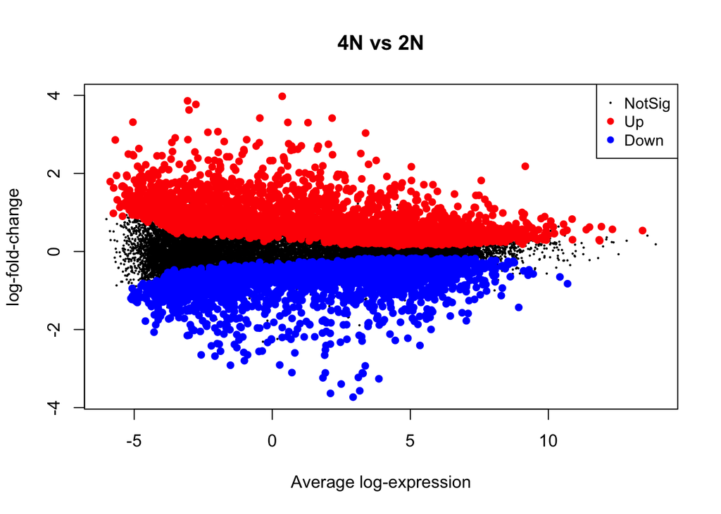

#### Gràfic de volcà

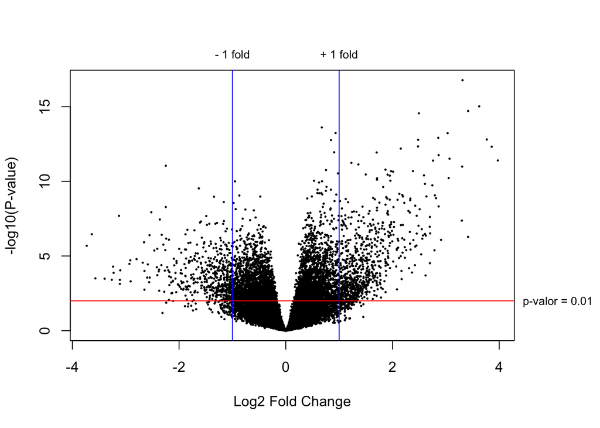

#### Heatmap dels gens més significatius

100 gens amb p-valor ajustat més baix:

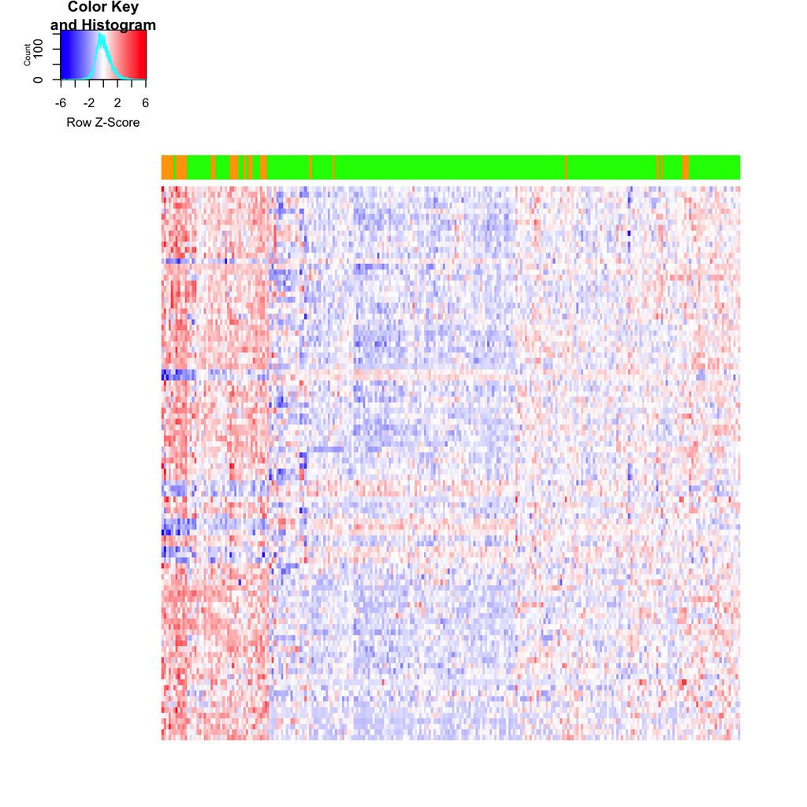

100 gens amb p-valor ajustat més baix després d’haver filtrat per aquells gens amb un logFC en valor absolut superior a 0.5 (aproximadament equivalent a FC superior a 1.4 o inferior a 0.7):

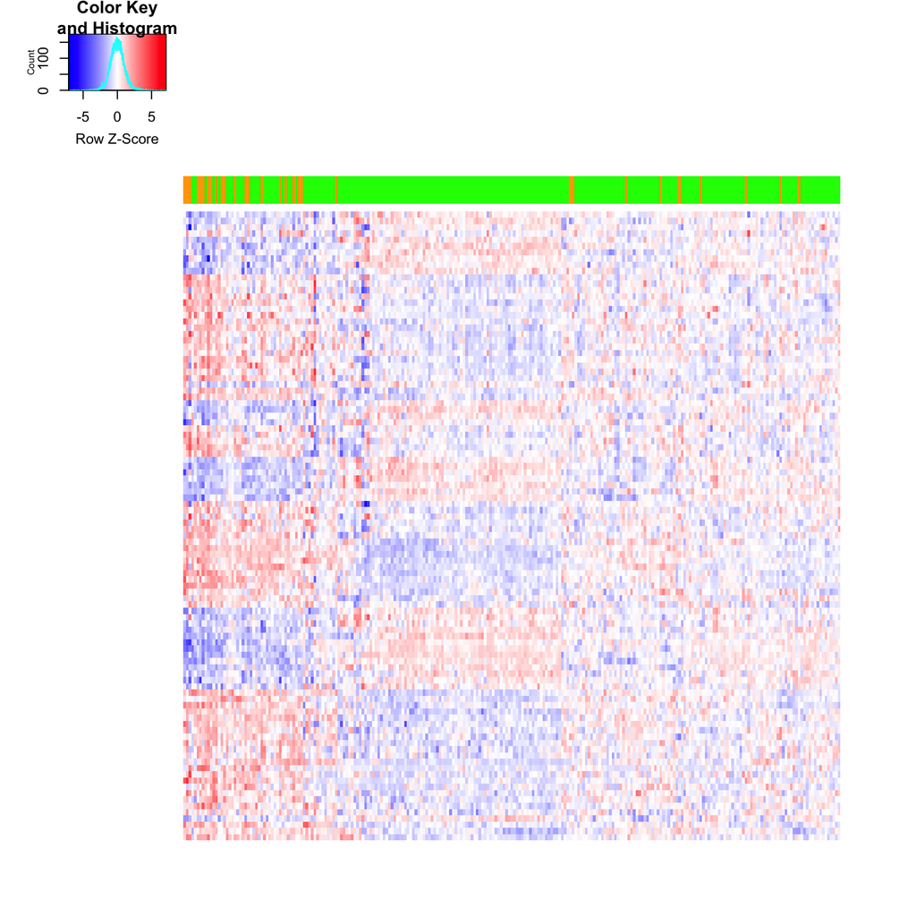

## Resultats de l’anàlisi d’enriquiment amb permutació de gene sets

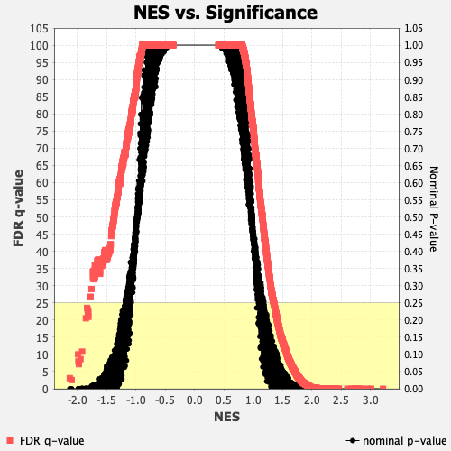

Termes enriquits al grup WGD

| NAME | FDR.q.val | NES |
| --- | --- | --- |
| GO_HUMORAL_IMMUNE_RESPONSE_MEDIATED_BY_CIRCULATING_IMMUNOGLOBULIN | 0 | 3.217197 |
| GO_B_CELL_MEDIATED_IMMUNITY | 0 | 3.013994 |
| GO_COMPLEMENT_ACTIVATION | 0 | 2.947875 |
| GO_REGULATION_OF_HUMORAL_IMMUNE_RESPONSE | 0 | 2.863267 |
| GO_FC_RECEPTOR_MEDIATED_STIMULATORY_SIGNALING_PATHWAY | 0 | 2.815820 |
| GO_POSITIVE_REGULATION_OF_B_CELL_ACTIVATION | 0 | 2.808091 |
| GO_HUMORAL_IMMUNE_RESPONSE | 0 | 2.793503 |
| GO_IMMUNOGLOBULIN_PRODUCTION | 0 | 2.764711 |
| GO_LYMPHOCYTE_MEDIATED_IMMUNITY | 0 | 2.751726 |
| GO_B_CELL_RECEPTOR_SIGNALING_PATHWAY | 0 | 2.740268 |
| GO_REGULATION_OF_B_CELL_ACTIVATION | 0 | 2.730543 |
| GO_ADAPTIVE_IMMUNE_RESPONSE_BASED_ON_SOMATIC_RECOMBINATION_OF_IMMUNE_RECEPTORS_BUILT_FROM_IMMUNOGLOBULIN_SUPERFAMILY_DOMAINS | 0 | 2.706295 |
| GO_PHAGOCYTOSIS_RECOGNITION | 0 | 2.676407 |
| GO_MEMBRANE_INVAGINATION | 0 | 2.607251 |
| GO_PRODUCTION_OF_MOLECULAR_MEDIATOR_OF_IMMUNE_RESPONSE | 0 | 2.462878 |
| GO_DEFENSE_RESPONSE_TO_BACTERIUM | 0 | 2.462651 |
| GO_POSITIVE_REGULATION_OF_LYMPHOCYTE_ACTIVATION | 0 | 2.434166 |
| GO_COTRANSLATIONAL_PROTEIN_TARGETING_TO_MEMBRANE | 0 | 2.413068 |
| GO_REGULATORY_T_CELL_DIFFERENTIATION | 0 | 2.409330 |
| GO_PHAGOCYTOSIS | 0 | 2.380988 |

Termes enriquits al grup no_WGD

| NAME | FDR.q.val | NES |
| --- | --- | --- |
| GO_ACTIVATION_OF_ADENYLATE_CYCLASE_ACTIVITY | 0.0307058 | -2.126502 |
| GO_CELLULAR_AMINO_ACID_CATABOLIC_PROCESS | 0.0255873 | -2.093999 |
| GO_ORGANIC_ACID_CATABOLIC_PROCESS | 0.1001627 | -1.983842 |
| GO_FATTY_ACID_CATABOLIC_PROCESS | 0.0795677 | -1.979917 |
| GO_MONOCARBOXYLIC_ACID_CATABOLIC_PROCESS | 0.0716712 | -1.971291 |
| GO_LIPID_OXIDATION | 0.0862344 | -1.943694 |
| GO_REGULATION_OF_VASCULAR_SMOOTH_MUSCLE_CELL_DIFFERENTIATION | 0.1078640 | -1.915343 |
| GO_REGULATION_OF_MEMBRANE_REPOLARIZATION | 0.2051199 | -1.851848 |
| GO_GLUTAMINE_FAMILY_AMINO_ACID_CATABOLIC_PROCESS | 0.2353391 | -1.830162 |
| GO_BRANCHED_CHAIN_AMINO_ACID_CATABOLIC_PROCESS | 0.2306823 | -1.822476 |
| GO_LIPID_MODIFICATION | 0.2213491 | -1.817582 |
| GO_GAMMA_AMINOBUTYRIC_ACID_SIGNALING_PATHWAY | 0.2235492 | -1.808054 |
| GO_ENDOTHELIUM_DEVELOPMENT | 0.2092370 | -1.807098 |
| GO_ADIPOSE_TISSUE_DEVELOPMENT | 0.2675486 | -1.778507 |
| GO_BLOOD_VESSEL_ENDOTHELIAL_CELL_PROLIFERATION_INVOLVED_IN_SPROUTING_ANGIOGENESIS | 0.2671204 | -1.771729 |
| GO_CELL_FATE_DETERMINATION | 0.2904301 | -1.756407 |
| GO_MEMBRANE_REPOLARIZATION | 0.3407429 | -1.733583 |
| GO_REGULATION_OF_CARDIAC_MUSCLE_CELL_MEMBRANE_REPOLARIZATION | 0.3248464 | -1.732689 |
| GO_REGULATION_OF_SYSTEMIC_ARTERIAL_BLOOD_PRESSURE_BY_CIRCULATORY_RENIN_ANGIOTENSIN | 0.3424229 | -1.722143 |
| GO_VASCULAR_SMOOTH_MUSCLE_CELL_DIFFERENTIATION | 0.3295413 | -1.720747 |

## Anàlisis d’immunitat

### ESTIMATE

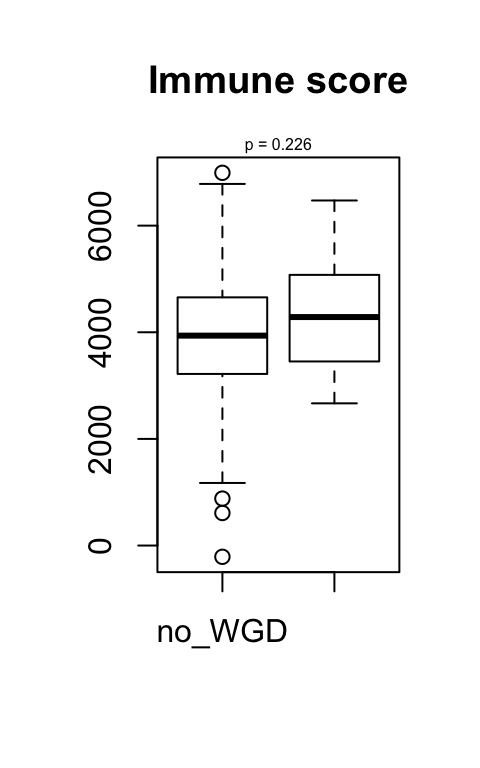

### Immunophenoscore

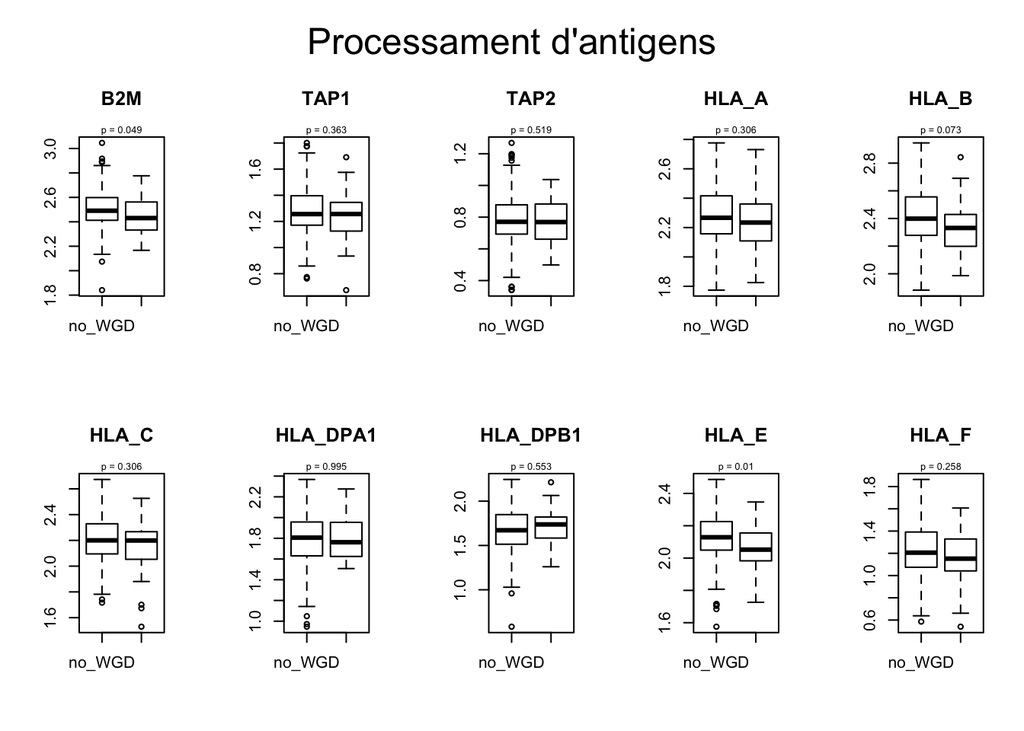

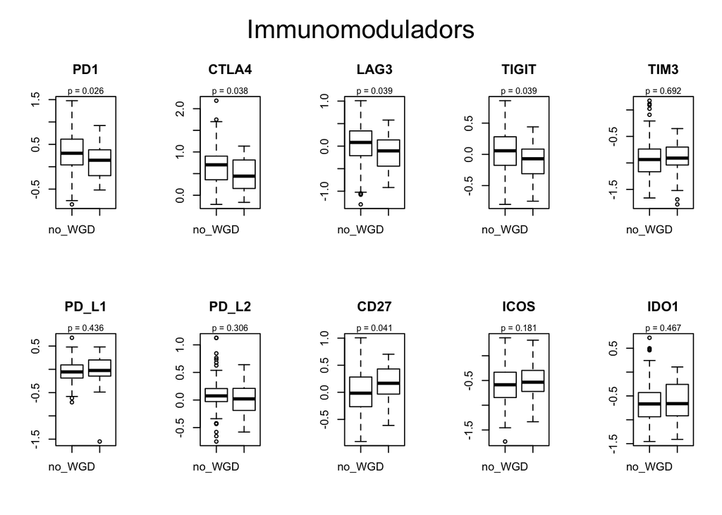

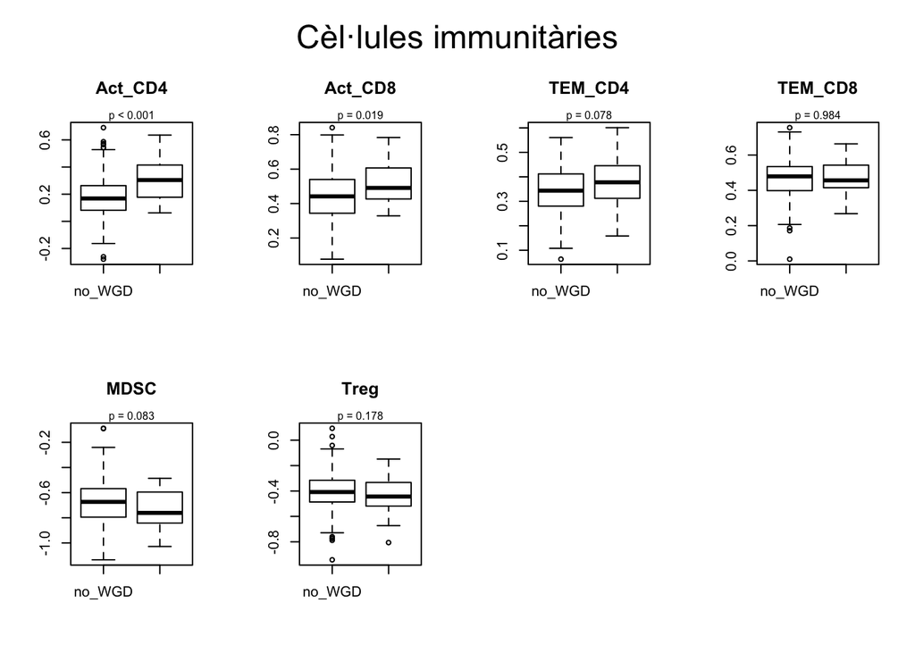

### Signatura 12-Chemokines

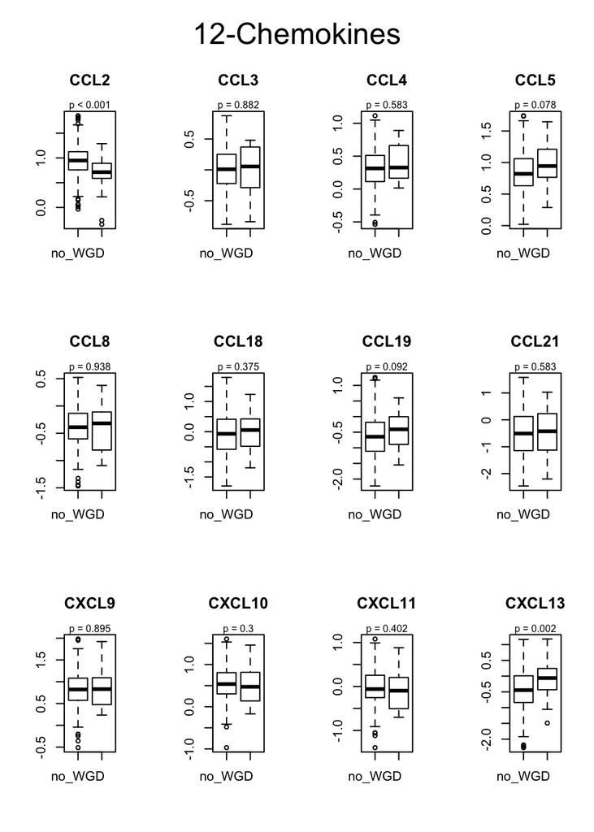